# Severe Weather Event Analysis

Florian Eiden

25 janvier 2015

# Synopsis

This analysis use the data published by the **National Weather Service**, to determine the classes of event having the most impact on the population health, and the greatest economic consequences. To do so we concentrate on the data **after 1990** as it is cleaner. We then match the 200+ event categories to the **48 official ones** using an algorithm (Jaro-Winkler distance). Then we **aggregate the data et plot it** accordingly.

# Data Processing

```r
# Session initialization
setwd("~/Documents/GitHub/RepData_PeerAssessment2")
Sys.setlocale("LC_TIME", "en_US")

library(ggplot2)
library(grid) #pushViewport
library(R.utils) #bunzip2
library(stringr) #str_trim
library(plyr) #count
library(stringdist) #stringdist
library(RColorBrewer)

sessionInfo()
```

```r
# Download from the web source and load it in CSV

download.file("https://d396qusza40orc.cloudfront.net/repdata%2Fdata%2FStormData.csv.bz2"
              , destfile = "StormData.csv.bz2", method = "curl")
download.file("https://d396qusza40orc.cloudfront.net/repdata%2Fpeer2_doc%2Fpd01016005curr.pdf"
              , destfile = "StormData_Documentation.pdf", method = "curl")
download.file("https://d396qusza40orc.cloudfront.net/repdata%2Fpeer2_doc%2FNCDC%20Storm%20Events-FAQ%20Page.pdf"
              , destfile = "StormData_FAQ.pdf", method = "curl")

bunzip2("StormData.csv.bz2", overwrite = FALSE, remove = FALSE)
```

We load the data using the following parameters:

```r
SD_Raw <- read.csv("StormData.csv", header = TRUE, sep = ",")
```

We also load a list of the 48 official event types, used for reconciliation latter:

```r
EVTYPE_Ref <- read.csv("EVTYPE_Ref.txt",header = TRUE, sep =",")
EVTYPE_Ref$EVTYPE <- toupper(str_trim(EVTYPE_Ref$EVTYPE))
EVTYPE_Ref$Designator <- toupper(str_trim(EVTYPE_Ref$Designator))
EVTYPE_Ref
```

```
##                      EVTYPE Designator
## 1     ASTRONOMICAL LOW TIDE          Z
## 2                 AVALANCHE          Z
## 3                  BLIZZARD          Z
## 4             COASTAL FLOOD          Z
## 5           COLD/WIND CHILL          Z
## 6               DEBRIS FLOW          C
## 7                 DENSE FOG          Z
## 8               DENSE SMOKE          Z
## 9                   DROUGHT          Z
## 10               DUST DEVIL          C
## 11               DUST STORM          Z
## 12           EXCESSIVE HEAT          Z
## 13  EXTREME COLD/WIND CHILL          Z
## 14              FLASH FLOOD          C
```

[output cut: 34 more lines]

We change the type of some colums and filter the data >= 1990

```r
SD_Raw$BGN_DATE <- as.Date(SD_Raw$BGN_DATE,"%m/%d/%Y")
SD_Raw_Modern <- subset(SD_Raw,format(SD_Raw$BGN_DATE,"%Y") >= 1990)

SD_Raw_Modern$EVTYPE <- toupper(str_trim(as.character(SD_Raw_Modern$EVTYPE)))

SD_Raw_Modern$PROPDMGEXP <- as.character(SD_Raw_Modern$PROPDMGEXP)
```

It has to be noted that some cleaning was required in order to calculate properly the Property Damage amounts:

```r
SD_Raw_Modern[SD_Raw_Modern$PROPDMGEXP == "-", c("PROPDMGEXP")] <- 1
SD_Raw_Modern[SD_Raw_Modern$PROPDMGEXP == "+", c("PROPDMGEXP")] <- 1
SD_Raw_Modern[SD_Raw_Modern$PROPDMGEXP == "", c("PROPDMGEXP")] <- 1
SD_Raw_Modern[SD_Raw_Modern$PROPDMGEXP == "?", c("PROPDMGEXP")] <- 1
SD_Raw_Modern[SD_Raw_Modern$PROPDMGEXP == "0", c("PROPDMGEXP")] <- 1
SD_Raw_Modern[SD_Raw_Modern$PROPDMGEXP == "1", c("PROPDMGEXP")] <- 10
SD_Raw_Modern[SD_Raw_Modern$PROPDMGEXP == "2", c("PROPDMGEXP")] <- 100
SD_Raw_Modern[SD_Raw_Modern$PROPDMGEXP == "3", c("PROPDMGEXP")] <- 1000
SD_Raw_Modern[SD_Raw_Modern$PROPDMGEXP == "4", c("PROPDMGEXP")] <- 1000*10
SD_Raw_Modern[SD_Raw_Modern$PROPDMGEXP == "5", c("PROPDMGEXP")] <- 1000*100
SD_Raw_Modern[SD_Raw_Modern$PROPDMGEXP == "6", c("PROPDMGEXP")] <- 1000*1000
SD_Raw_Modern[SD_Raw_Modern$PROPDMGEXP == "7", c("PROPDMGEXP")] <- 1000*1000*10
SD_Raw_Modern[SD_Raw_Modern$PROPDMGEXP == "8", c("PROPDMGEXP")] <- 1000*1000*100
SD_Raw_Modern[tolower(SD_Raw_Modern$PROPDMGEXP) == "h", c("PROPDMGEXP")] <- 100
SD_Raw_Modern[tolower(SD_Raw_Modern$PROPDMGEXP) == "k", c("PROPDMGEXP")] <- 1000
SD_Raw_Modern[tolower(SD_Raw_Modern$PROPDMGEXP) == "m", c("PROPDMGEXP")] <- 1000*1000
SD_Raw_Modern[tolower(SD_Raw_Modern$PROPDMGEXP) == "b", c("PROPDMGEXP")] <- 1000*1000*1000

SD_Raw_Modern$CROPDMGEXP <- as.character(SD_Raw_Modern$CROPDMGEXP)

SD_Raw_Modern[SD_Raw_Modern$CROPDMGEXP == "", c("CROPDMGEXP")] <- 1
SD_Raw_Modern[SD_Raw_Modern$CROPDMGEXP == "0", c("CROPDMGEXP")] <- 1
SD_Raw_Modern[SD_Raw_Modern$CROPDMGEXP == "?", c("CROPDMGEXP")] <- 1
SD_Raw_Modern[SD_Raw_Modern$CROPDMGEXP == "2", c("CROPDMGEXP")] <- 100
SD_Raw_Modern[tolower(SD_Raw_Modern$CROPDMGEXP) == "h", c("CROPDMGEXP")] <- 100
SD_Raw_Modern[tolower(SD_Raw_Modern$CROPDMGEXP) == "k", c("CROPDMGEXP")] <- 1000
SD_Raw_Modern[tolower(SD_Raw_Modern$CROPDMGEXP) == "m", c("CROPDMGEXP")] <- 1000*1000
SD_Raw_Modern[tolower(SD_Raw_Modern$CROPDMGEXP) == "b", c("CROPDMGEXP")] <- 1000*1000*1000

SD_Raw_Modern$TOTALDMG <- SD_Raw_Modern$PROPDMG * as.numeric(SD_Raw_Modern$PROPDMGEXP) +
                          SD_Raw_Modern$CROPDMG * as.numeric(SD_Raw_Modern$CROPDMGEXP)
```

We aggregate the data set for a better understanding:

```r
h1 <- aggregate(
     cbind(
          SD_Raw_Modern$FATALITIES,
          SD_Raw_Modern$INJURIES,
          SD_Raw_Modern$TOTALDMG
          )
    ,by=list(
            format(SD_Raw_Modern$BGN_DATE,"%Y")
            ,SD_Raw_Modern$EVTYPE
      )
    ,FUN=sum
  )

names(h1) <- c("YEAR","EVTYPE","FATALITIES","INJURIES","TOTALDMG")

h1 <- subset(h1,h1$FATALITIES + h1$INJURIES + h1$TOTALDMG > 0 )

head(h1,10)
```

```
##    YEAR                 EVTYPE FATALITIES INJURIES TOTALDMG
## 1  1994                      ?          0        0     5000
## 8  1997    AGRICULTURAL FREEZE          0        0 28820000
## 9  1994          APACHE COUNTY          0        0     5000
## 11 2003 ASTRONOMICAL HIGH TIDE          0        0  6090000
## 12 2004 ASTRONOMICAL HIGH TIDE          0        0  2500000
## 13 2005 ASTRONOMICAL HIGH TIDE          0        0   835000
## 14 2007  ASTRONOMICAL LOW TIDE          0        0   120000
## 15 2008  ASTRONOMICAL LOW TIDE          0        0   200000
## 19 1993               AVALANCE          1        0        0
## 20 1993              AVALANCHE          0        0     5000
```

The Event label reconciliation is done using `stringdist`and a Jaro-Winkler distance calculation:

```r
## carthesian product
temp_01 <- merge(unique(h1$EVTYPE),EVTYPE_Ref,by=NULL)
temp_01$x <- as.character(temp_01$x)
names(temp_01) <- c("EVTYPE.x","EVTYPE.y","Designator")

## for each combination of EVTYPE, we calculate the distance
temp_01$check = 1 - stringdist(temp_01$EVTYPE.x,temp_01$EVTYPE.y,method='jw',p=0.1)

## then we go look for the higher one
temp_02 <- aggregate(temp_01$check,by=list(temp_01$EVTYPE.x),FUN=max)
names(temp_02) <- c("EVTYPE.x","check")

## and keep only the best ones
temp_02 <- subset(temp_02,temp_02$check > 0.8)
temp_03 <- merge(temp_01,temp_02,by=c("EVTYPE.x","check"),all=FALSE)

## and also remove the matches where more than one result was returned
temp_03 <- merge(temp_03,count(temp_03,"EVTYPE.x"),by="EVTYPE.x")
temp_03 <- subset(temp_03,temp_03$freq == 1)

## reconcile everything
h1 <- merge(h1,temp_03,by.x="EVTYPE",by.y="EVTYPE.x",all.x=TRUE)
names(h1) <- c("EVTYPE","YEAR","FATALITIES","INJURIES","TOTALDMG","EVTYPE_CONFIDENCE","EVTYPE_REF48","DESIGNATOR","EVTYPE_FREQUENCY")
h1$EVTYPE_REF48[is.na(h1$EVTYPE_REF48)] <- "UNKOWN"
h1$DESIGNATOR[is.na(h1$DESIGNATOR)] <- "UNKOWN"
```

That gives us a tidy dataset for plotting and analysis:

```r
head(h1,10)
```

```
##                    EVTYPE YEAR FATALITIES INJURIES TOTALDMG
## 1                       ? 1994          0        0     5000
## 2     AGRICULTURAL FREEZE 1997          0        0 28820000
## 3           APACHE COUNTY 1994          0        0     5000
## 4  ASTRONOMICAL HIGH TIDE 2004          0        0  2500000
## 5  ASTRONOMICAL HIGH TIDE 2005          0        0   835000
## 6  ASTRONOMICAL HIGH TIDE 2003          0        0  6090000
## 7   ASTRONOMICAL LOW TIDE 2007          0        0   120000
## 8   ASTRONOMICAL LOW TIDE 2008          0        0   200000
## 9                AVALANCE 1993          1        0        0
## 10              AVALANCHE 2001         18        6    44000
##    EVTYPE_CONFIDENCE          EVTYPE_REF48 DESIGNATOR EVTYPE_FREQUENCY
## 1                 NA                UNKOWN     UNKOWN               NA
## 2                 NA                UNKOWN     UNKOWN               NA
## 3                 NA                UNKOWN     UNKOWN               NA
## 4          0.9239538 ASTRONOMICAL LOW TIDE          Z                1
## 5          0.9239538 ASTRONOMICAL LOW TIDE          Z                1
## 6          0.9239538 ASTRONOMICAL LOW TIDE          Z                1
## 7          1.0000000 ASTRONOMICAL LOW TIDE          Z                1
## 8          1.0000000 ASTRONOMICAL LOW TIDE          Z                1
## 9          0.9777778             AVALANCHE          Z                1
## 10         1.0000000             AVALANCHE          Z                1
```

# Results

```r
#Create a custom color scale to have the same colors in each figures
myColors <- brewer.pal(4,"Set2")
names(myColors) <- levels(factor(h1$DESIGNATOR))
```

#### Question 1

Across the United States, which types of events (as indicated in the EVTYPE variable) are most harmful with respect to population health?

###### For Injuries

**Figure 1:**

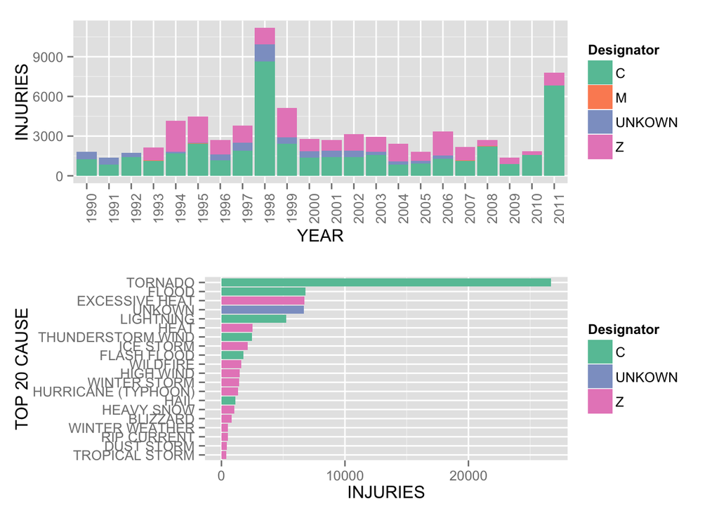

```r
# plot
q1_data <- aggregate(h1$INJURIES,by=list(h1$YEAR,h1$DESIGNATOR),FUN=sum)
names(q1_data)<-c("YEAR","DESIGNATOR","INJURIES")
q1_data$fDESIGNATOR <- factor(q1_data$DESIGNATOR)
q1 <- ggplot(q1_data,aes(x=YEAR, y=INJURIES, fill=fDESIGNATOR))
q1 <- q1 + geom_bar(stat="identity")
q1 <- q1 + theme(axis.text.x = element_text(angle = 90, hjust = 1))
q1 <- q1 + scale_fill_manual("Designator", values = myColors)

q3_data <- aggregate(h1$INJURIES, by=list(h1$EVTYPE_REF48,h1$DESIGNATOR),FUN=sum)
names(q3_data)<-c("EVENT","DESIGNATOR","INJURIES")
q3_data$fDESIGNATOR <- factor(q3_data$DESIGNATOR)
q3_data <- head(q3_data[order(q3_data$INJURIES,decreasing=T),],20)
q3 <- ggplot(q3_data,aes(x=reorder(EVENT,INJURIES), y=INJURIES, fill=fDESIGNATOR))
q3 <- q3 + geom_bar(stat="identity") + coord_flip()  + xlab("TOP 20 CAUSE")
q3 <- q3 + scale_fill_manual("Designator", values = myColors)

pushViewport(viewport(layout = grid.layout(2, 1)))
print(q1, vp = viewport(layout.pos.row = 1, layout.pos.col = 1))
print(q3, vp = viewport(layout.pos.row = 2, layout.pos.col = 1))
```

###### For Fatalities

**Figure 2:**

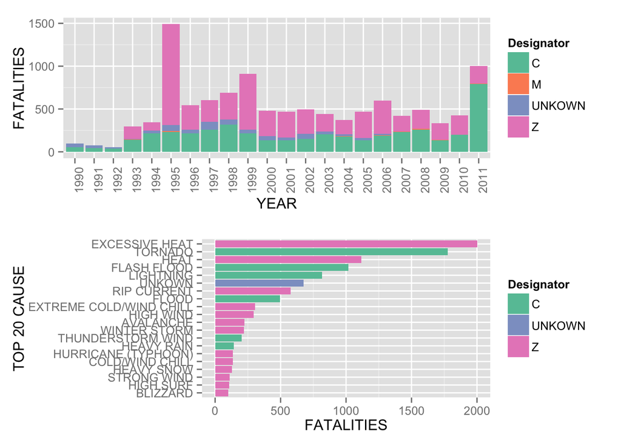

```r
q2_data <- aggregate(h1$FATALITIES,by=list(h1$YEAR,h1$DESIGNATOR),FUN=sum)
names(q2_data)<-c("YEAR","DESIGNATOR","FATALITIES")
q2_data$fDESIGNATOR <- factor(q2_data$DESIGNATOR)
q2 <- ggplot(q2_data,aes(x=YEAR, y=FATALITIES, fill=fDESIGNATOR))
q2 <- q2 + geom_bar(stat="identity")
q2 <- q2 + theme(axis.text.x = element_text(angle = 90, hjust = 1))
q2 <- q2 + scale_fill_manual("Designator", values = myColors)

q4_data <- aggregate(h1$FATALITIES, by=list(h1$EVTYPE_REF48,h1$DESIGNATOR),FUN=sum)
names(q4_data)<-c("EVENT","DESIGNATOR","FATALITIES")
q4_data$fDESIGNATOR <- factor(q4_data$DESIGNATOR)
q4_data <- head(q4_data[order(q4_data$FATALITIES,decreasing=T),],20)
q4 <- ggplot(q4_data,aes(x=reorder(EVENT,FATALITIES), y=FATALITIES, fill=fDESIGNATOR))
q4 <- q4 + geom_bar(stat="identity") + coord_flip() + xlab("TOP 20 CAUSE")
q4 <- q4 + scale_fill_manual("Designator", values = myColors)

pushViewport(viewport(layout = grid.layout(2, 1)))
print(q2, vp = viewport(layout.pos.row = 1, layout.pos.col = 1))
print(q4, vp = viewport(layout.pos.row = 2, layout.pos.col = 1))
```

#### Question 2

Across the United States, which types of events have the greatest economic consequences? **Figure 3:**

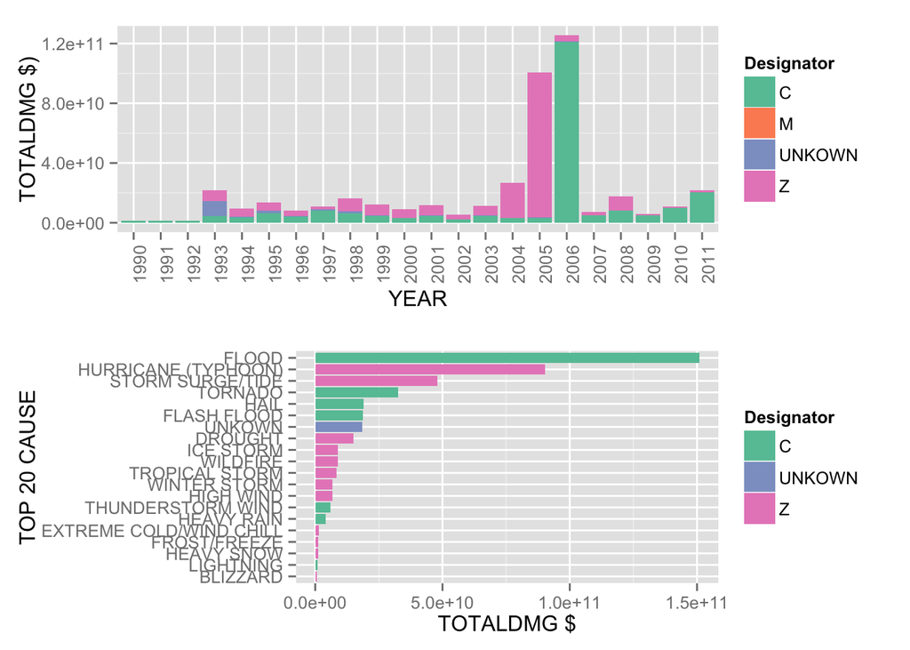

```r
# plot
q5_data <- aggregate(h1$TOTALDMG,by=list(h1$YEAR,h1$DESIGNATOR),FUN=sum)
names(q5_data)<-c("YEAR","DESIGNATOR","TOTALDMG")
q5_data$fDESIGNATOR <- factor(q5_data$DESIGNATOR)
q5 <- ggplot(q5_data,aes(x=YEAR, y=TOTALDMG, fill=fDESIGNATOR))
q5 <- q5 + geom_bar(stat="identity")
q5 <- q5 + theme(axis.text.x = element_text(angle = 90, hjust = 1))
q5 <- q5 + scale_fill_manual("Designator", values = myColors) + ylab("TOTALDMG $)")

q6_data <- aggregate(h1$TOTALDMG, by=list(h1$EVTYPE_REF48,h1$DESIGNATOR),FUN=sum)
names(q6_data)<-c("EVENT","DESIGNATOR","TOTALDMG")
q6_data$fDESIGNATOR <- factor(q6_data$DESIGNATOR)
q6_data <- head(q6_data[order(q6_data$TOTALDMG,decreasing=T),],20)
q6 <- ggplot(q6_data,aes(x=reorder(EVENT,TOTALDMG), y=TOTALDMG, fill=fDESIGNATOR))
q6 <- q6 + geom_bar(stat="identity") + coord_flip()  + xlab("TOP 20 CAUSE") + ylab("TOTALDMG $")
q6 <- q6 + scale_fill_manual("Designator", values = myColors)

pushViewport(viewport(layout = grid.layout(2, 1)))
print(q5, vp = viewport(layout.pos.row = 1, layout.pos.col = 1))
print(q6, vp = viewport(layout.pos.row = 2, layout.pos.col = 1))
```